# Bonanza Creek Snowshoe Hairs Mini Report

Jaxon Stuhr

11/9/2021

## Introduction

This report explores juvenile snowshoe hare populations in the Bonanza Creek Experimental Forest in Alaska from 1999 to 2012. Hare weights are analyzed along with relationship to sex, observed site, and hind foot length. Observed sites include “Bonanza Riparian”, “Bonanaza Mature”, and “Bonanza Black Spruce”, about which additional metadata can be found in Kielland et al.

## Data and Analyses

Snowshoe hare trap counts and measurements were provided by Kielland et al., working at the Bonanza Creek Long Term Ecological Research (LTER) site in Alaska. Included are data on over 3000 hare trappings, however this report examines only the 378 of those that were juveniles. The data was collected from the three sites referenced above over the years 1999 - 2012. This report includes visualizations of total trap counts by year (Fig 1), analysis of the relationship between trapping site, hare size, and hare weight (Fig 2, Table 1), and an examination of the relationship between hind foot length and weight (Fig 3). Statistical methods including an unpaired t-test, a Cohen’s *d* effect size calculation, and a linear regression were performed to best assess and understand relationships.

## Juvenile Hare Initial Investigation

### Annual juvenile hare trap counts

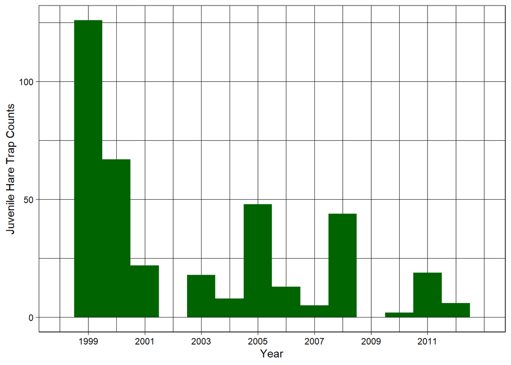

Fig 1: Juvenile hare trap counts at Bonanza Creek Experimental Forest for years 1999 - 2012

#### Analyses:

The maximum number of hare trappings in a given year was 126 and occurred in 1999, while the minimum was zero and occurred in both 2002 and 2009. The mean annual trappings was 31.5 and the median was 18.5. The disparity between these two is due to the huge difference in trappings between 1999 and any other year, thus the 1999 trappings pulled up the mean. There’s a slight trend of decreasing hare trappings, however, this depends heavily on the 1999 data point which is a stark outlier. To better understand this trend one would have to account for the annual effort, or number of traps laid and how often. With the given data it is impossible to tell if differences between years are due to changing hare populations or changing effort put in to trapping.

### Visualize juvenile hare weights

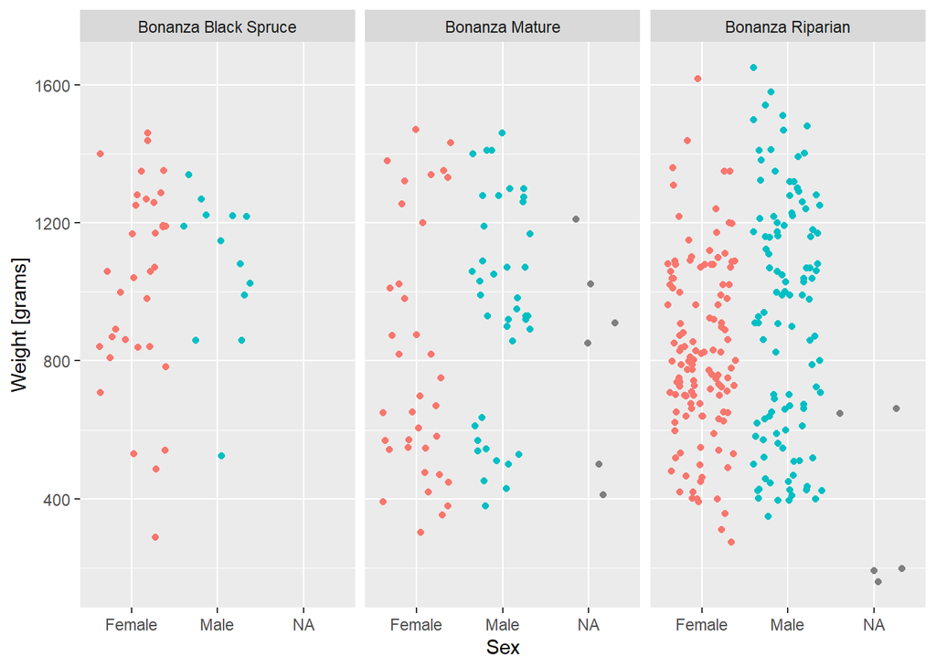

Fig 2: Juvenile hare weights [g] at three Bonanza sites sorted by site and sex for hares trapped between 1999 and 2012

#### Analyses:

At all sites male hares weighed on average 51 to 141.9 grams more than females. Hares at the Bonanaza black spruce site also weighed more on average that at the mature and riparian sites, but there was not a large variation from site to site or by sex.

### Juvenile weight comparison (male & female snowshoe hares)

Table 1: Juvenile Hare Weights for Bonanza Sites

| Sex | Mean Weight [g] | Standard Deviation [g] | Sample Size |
| --- | --- | --- | --- |
| Female | 855.4 | 292.3 | 200 |
| Male | 945.9 | 333.2 | 163 |
| NA | 614.5 | 357.6 | 15 |

#### Analyses

On average, trapped male juvenile hares weighed 90.5 grams, or 10%, more than trapped female juvenile hares. Examining the effect of hare sex on weight with a t-test, we find that there is less than a 1% chance of randomly drawing samples from populations with the same mean that are at least as different as the male and female hairs were. The effect, however, was small (Cohen’s *d* = 0.29).

### Relationship between juvenile weight & hind foot length

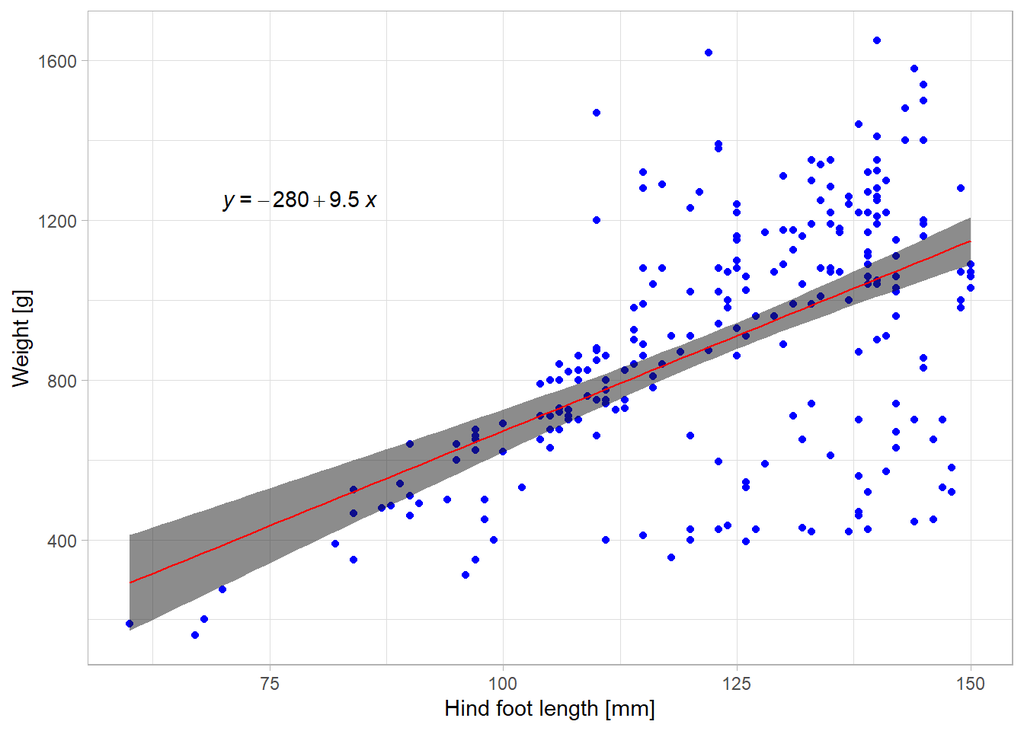

Fig 3: Juvenile hare weights [g] as a function of hind foot length [mm] at three Bonanza sites, hares trapped between 1999 and 2012 with fitted linear regression

#### Analysis

The fitted linear regression model states that for every 1mm increase in hind foot length, the hares’ weight increase by 9.5 grams. The fitted line had an R<sup>2</sup> = 0.3 meaning only 30% of the variance in weight could be explained by changes in hind foot length. From a Pearson’s *r* value of 0.55 we see that the variables (hind foot length and weight) are moderately correlated. The assumption of homoscedasticity, which is required for linear regression, appears to not apply as we can see in the scatter plot that variance in weight increases as hind foot length gets bigger.

## References

Kielland, K., F.S. Chapin, R.W. Ruess, and Bonanza Creek LTER. 2017. Snowshoe hare physical data in Bonanza Creek Experimental Forest: 1999-Present ver 22. Environmental Data Initiative. https://doi.org/10.6073/pasta/03dce4856d79b91557d8e6ce2cbcdc14

Wickham et al., (2019). Welcome to the tidyverse. Journal of Open Source Software, 4(43), 1686, https://doi.org/10.21105/joss.01686

Kirill Müller (2020). here: A Simpler Way to Find Your Files. R package version 1.0.1. https://CRAN.R-project.org/package=here

Torchiano M (2020). *effsize: Efficient Effect Size Computation*. doi: 10.5281/zenodo.1480624 (URL: https://doi.org/10.5281/zenodo.1480624), R package version 0.8.1, <URL: https://CRAN.R-project.org/package=effsize>.

Hao Zhu (2021). kableExtra: Construct Complex Table with ‘kable’ and Pipe Syntax. R package version 1.3.4. https://CRAN.R-project.org/package=kableExtra

Garrett Grolemund, Hadley Wickham (2011). Dates and Times Made Easy with lubridate. Journal of Statistical Software, 40(3), 1-25. URL https://www.jstatsoft.org/v40/i03/.

Alboukadel Kassambara (2020). ggpubr: ‘ggplot2’ Based Publication Ready Plots. R package version 0.4.0. https://CRAN.R-project.org/package=ggpubr